# A causal workflow in R with coupon marketing data

2025-12-04

This post accompanies the talk presented at [Fifth Elephant Winter 2025](https://hasgeek.com/fifthelephant/2025-winter/schedule). The slides are available here

We walk through a complete causal inference workflow using real marketing data from the [AmExpert 2019 Kaggle competition](https://www.kaggle.com/datasets/vasudeva009/predicting-coupon-redemption). The dataset contains transaction records, coupon assignments, and customer demographics from a retail store that ran 18 marketing campaigns. Our goal is to estimate the causal effect of receiving specific coupon types on customer spending during campaign periods.

Our analysis follows the methodology of [Langen & Huber (2023)](https://journals.plos.org/plosone/article?id=10.1371/journal.pone.0278937), who applied causal machine learning to evaluate coupon effectiveness. Their key finding: **drugstore coupons have a significant positive effect on sales**, while **ready-to-eat food coupons show no significant effect**. We replicate this finding using a simplified classical approach, demonstrating how DAG-based identification translates directly into a regression specification.

### The Causal Structure

We model the coupon-sales relationship with the following DAG:

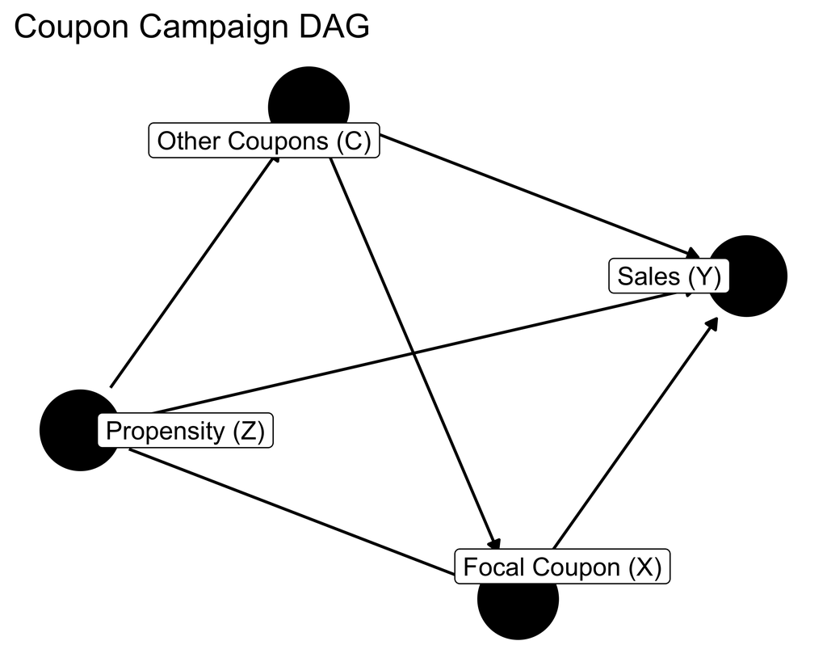

```r
# Simple visualization for HTML output
library(ggdag)
dag <- dagify(
  Y ~ X + Z + C,
  X ~ Z + C,
  C ~ Z,
  exposure = "X",
  outcome = "Y",
  labels = c(Y = "Sales (Y)", X = "Focal Coupon (X)",
             Z = "Propensity (Z)", C = "Other Coupons (C)")
)
ggdag(dag, text = FALSE, use_labels = "label") +
  theme_dag_blank() +
  labs(title = "Coupon Campaign DAG")
```

**Variables:**

- **Z (Propensity)**: Pre-campaign average daily spending—a scalar index of how likely a customer is to buy. High-Z customers are more likely to receive coupons (retailer targeting) *and* more likely to spend (baseline behavior).
- **X (Focal Coupon)**: Binary indicator for whether the customer received a coupon of the category we’re studying (e.g., drugstore).
- **C (Other Coupons)**: Binary indicator for whether the customer received coupons from *other* categories in the same campaign.
- **Y (Sales)**: Average daily expenditures during the campaign period.

## Data Preparation

The dataset consists of six CSV files: `train.csv` (coupon assignments), `campaign_data.csv` (campaign dates), `customer_transaction_data.csv` (purchase records), `item_data.csv` (product categories), `coupon_item_mapping.csv` (coupon-to-product mappings), and `customer_demographics.csv`. We construct a customer × campaign panel where each row contains the propensity index Z, treatment indicators X and C, and outcome Y.

Following [Langen & Huber (2023)](https://journals.plos.org/plosone/article?id=10.1371/journal.pone.0278937), we compare each coupon category against customers who received **no coupons at all** (not “no coupon of this type”). This ensures the control group is uncontaminated by other coupon effects. The transaction data contains extreme outliers (wholesale/B2B accounts with transactions in the millions), which we filter at the 95th percentile to focus on retail customers.

```r
# =============================================================================
# LOAD DATA
# =============================================================================
train                <- readr::read_csv("~/Documents/causal_talk_5thel/mlcausal_data/train.csv")
campaign_data        <- readr::read_csv("~/Documents/causal_talk_5thel/mlcausal_data/campaign_data.csv")
coupon_item_mapping  <- readr::read_csv("~/Documents/causal_talk_5thel/mlcausal_data/coupon_item_mapping.csv")
customer_demo        <- readr::read_csv("~/Documents/causal_talk_5thel/mlcausal_data/customer_demographics.csv")
customer_txn         <- readr::read_csv("~/Documents/causal_talk_5thel/mlcausal_data/customer_transaction_data.csv")
item_data            <- readr::read_csv("~/Documents/causal_talk_5thel/mlcausal_data/item_data.csv")

# =============================================================================
# DEFINE COUPON CATEGORIES (following Langen & Huber)
# =============================================================================
ready2eat_cats     <- c("Bakery", "Restaurant", "Prepared Food", "Dairy, Juices & Snacks")
drugstore_cats     <- c("Pharmaceutical", "Skin & Hair Care")
other_food_cats    <- c("Grocery", "Salads", "Vegetables (cut)", "Natural Products")
other_nonfood_cats <- c("Flowers & Plants", "Garden", "Travel", "Miscellaneous")

# =============================================================================
# CLEAN TRANSACTIONS (remove B2B/wholesale outliers)
# =============================================================================
customer_txn <- customer_txn |>
  dplyr::mutate(total_value = quantity * selling_price)

threshold <- min(quantile(customer_txn$total_value, 0.95, na.rm = TRUE), 2000)

customer_txn_clean <- customer_txn |>
  dplyr::filter(total_value <= threshold)

# =============================================================================
# PARSE CAMPAIGN DATES
# =============================================================================
campaign_data <- campaign_data |>
  dplyr::mutate(
    start_date = lubridate::dmy(start_date),
    end_date   = lubridate::dmy(end_date),
    camp_days  = as.numeric(end_date - start_date) + 1
  )

# =============================================================================
# BUILD CUSTOMER-CAMPAIGN PANEL
# =============================================================================
# Treated: customers who received coupons
cust_with_coupons <- train |>
  dplyr::distinct(customer_id, campaign_id)

# Control candidates: customers who transacted during campaigns but got no coupons
cust_transacted <- customer_txn_clean |>
  dplyr::select(customer_id, date) |>
  tidyr::crossing(campaign_data |> dplyr::select(campaign_id, start_date, end_date)) |>
  dplyr::filter(date >= start_date, date <= end_date) |>
  dplyr::distinct(customer_id, campaign_id)

# Union of both sources
cust_camp_full <- dplyr::bind_rows(cust_with_coupons, cust_transacted) |>
  dplyr::distinct(customer_id, campaign_id) |>
  dplyr::left_join(campaign_data, by = "campaign_id") |>
  dplyr::mutate(
    received_any_coupon = paste(customer_id, campaign_id, sep = "_") %in%
      paste(cust_with_coupons$customer_id, cust_with_coupons$campaign_id, sep = "_")
  )

# =============================================================================
# CONSTRUCT Z: Pre-campaign propensity index (true daily average)
# =============================================================================
pre_window <- 60

pre_spend <- customer_txn_clean |>
  dplyr::inner_join(
    cust_camp_full |> dplyr::select(customer_id, campaign_id, start_date),
    by = "customer_id"
  ) |>
  dplyr::filter(date >= start_date - pre_window, date < start_date) |>
  dplyr::group_by(customer_id, campaign_id) |>
  dplyr::summarise(
    pre_total = sum(total_value, na.rm = TRUE),
    .groups = "drop"
  )

cust_camp <- cust_camp_full |>
  dplyr::left_join(pre_spend, by = c("customer_id", "campaign_id")) |>
  dplyr::mutate(
    pre_total = tidyr::replace_na(pre_total, 0),
    Z = pre_total / pre_window  # True daily average over full 60-day window
  )

# =============================================================================
# CONSTRUCT X: Treatment indicators by coupon category
# =============================================================================
coupon_with_cat <- coupon_item_mapping |>
  dplyr::left_join(item_data, by = "item_id") |>
  dplyr::group_by(coupon_id) |>
  dplyr::summarise(main_category = names(sort(table(category), decreasing = TRUE))[1]) |>
  dplyr::mutate(
    is_ready2eat    = main_category %in% ready2eat_cats,
    is_drugstore    = main_category %in% drugstore_cats,
    is_other_food   = main_category %in% other_food_cats,
    is_other_nonfood = main_category %in% other_nonfood_cats
  )

treatment_flags <- train |>
  dplyr::select(customer_id, campaign_id, coupon_id) |>
  dplyr::left_join(coupon_with_cat, by = "coupon_id") |>
  dplyr::group_by(customer_id, campaign_id) |>
  dplyr::summarise(
    X_ready2eat     = as.integer(any(is_ready2eat, na.rm = TRUE)),
    X_drugstore     = as.integer(any(is_drugstore, na.rm = TRUE)),
    X_other_food    = as.integer(any(is_other_food, na.rm = TRUE)),
    X_other_nonfood = as.integer(any(is_other_nonfood, na.rm = TRUE)),
    n_coupons       = dplyr::n(),
    .groups = "drop"
  )

cust_camp <- cust_camp |>
  dplyr::left_join(treatment_flags, by = c("customer_id", "campaign_id")) |>
  dplyr::mutate(
    across(starts_with("X_"), ~tidyr::replace_na(.x, 0L)),
    n_coupons  = tidyr::replace_na(n_coupons, 0L),
    any_coupon = as.integer(n_coupons > 0)
  )

# =============================================================================
# CONSTRUCT Y: Campaign-period average daily spending
# =============================================================================
txn_daily <- customer_txn_clean |>
  dplyr::group_by(customer_id, date) |>
  dplyr::summarise(daily_spend = sum(total_value, na.rm = TRUE), .groups = "drop")

campaign_spend <- cust_camp |>
  dplyr::distinct(customer_id, campaign_id, start_date, end_date, camp_days) |>
  dplyr::left_join(txn_daily, by = "customer_id", relationship = "many-to-many") |>
  dplyr::filter(date >= start_date, date <= end_date) |>
  dplyr::group_by(customer_id, campaign_id, camp_days) |>
  dplyr::summarise(Y = sum(daily_spend, na.rm = TRUE) / first(camp_days), .groups = "drop")

analysis_df <- cust_camp |>
  dplyr::left_join(campaign_spend, by = c("customer_id", "campaign_id", "camp_days")) |>
  dplyr::mutate(Y = tidyr::replace_na(Y, 0))

# Trim Y outliers at 99th percentile
y_99 <- quantile(analysis_df$Y, 0.99, na.rm = TRUE)
analysis_df <- analysis_df |> dplyr::filter(Y <= y_99)

# =============================================================================
# BUILD ANALYSIS SAMPLES (Langen & Huber methodology)
# =============================================================================
# For each coupon type: compare (has this coupon) vs (no coupons at all)
# C_other = 1 if customer received OTHER coupon types

df_drugstore <- analysis_df |>
  dplyr::filter(X_drugstore == 1 | any_coupon == 0) |>
  dplyr::mutate(
    X = X_drugstore,
    C_other = as.integer(X_ready2eat == 1 | X_other_food == 1 | X_other_nonfood == 1)
  ) |>
  dplyr::select(customer_id, campaign_id, Z, X, Y, C_other)

df_ready2eat <- analysis_df |>
  dplyr::filter(X_ready2eat == 1 | any_coupon == 0) |>
  dplyr::mutate(
    X = X_ready2eat,
    C_other = as.integer(X_drugstore == 1 | X_other_food == 1 | X_other_nonfood == 1)
  ) |>
  dplyr::select(customer_id, campaign_id, Z, X, Y, C_other)
```

```r
sample_sizes <- tibble::tibble(
  coupon_type = c("Drugstore", "Ready-to-eat"),
  n           = c(nrow(df_drugstore), nrow(df_ready2eat)),
  treated     = c(sum(df_drugstore$X == 1), sum(df_ready2eat$X == 1)),
  control     = c(sum(df_drugstore$X == 0), sum(df_ready2eat$X == 0))
)

sample_sizes |>
  knitr::kable(
    col.names = c("Coupon type", "N", "Treated (X = 1)", "Control (X = 0)"),
    caption   = "Sample sizes by coupon type and treatment status"
  ) |>
  kableExtra::kable_styling(full_width = FALSE)
```

Sample sizes by coupon type and treatment status

| Coupon type | N | Treated (X = 1) | Control (X = 0) |
| --- | --- | --- | --- |
| Drugstore | 26577 | 3759 | 22818 |
| Ready-to-eat | 24831 | 2013 | 22818 |

## Traditional Causal Inference Workflow

### DAG Specification and Identification

We have already defined the DAG in `dagitty` and now, we can use `dosearch` to verify that the causal effect is identifiable:

```r
# Check adjustment sets
dagitty::adjustmentSets(dag, exposure = "X", outcome = "Y")
```

```
## { C, Z }
```

```r
# Verify with dosearch
data_spec  <- "P(X, Y, Z, C)"
query_spec <- "P(Y | do(X))"

dosearch::dosearch(data_spec, query_spec, dag)
```

```
## \sum_{C,Z}\left(p(C,Z)p(Y|X,C,Z)\right)
```

$$\sum_{C,Z}p(C,Z)p(Y|X,C,Z)$$

The backdoor criterion confirms that conditioning on **{Z, C}** blocks all non-causal paths from X to Y. This translates directly to the regression specification:

$$Y_i = \alpha + \tau X_i + \beta Z_i + \gamma C_i + \varepsilon_i$$

where $\hat{\tau}$ estimates the Average Treatment Effect (ATE) under the assumption of no unmeasured confounding.

### ATE Estimation

#### Drugstore Coupons

```r
# Naive estimate (no adjustment - confounded!)
m_drug_naive <- lm(Y ~ X, data = df_drugstore)
naive_drug <- broom::tidy(m_drug_naive, conf.int = TRUE) |>
  dplyr::filter(term == "X") |>
  dplyr::mutate(model = "Naive")

# Adjusted estimate (backdoor criterion satisfied)
m_drug_adj <- lm(Y ~ X + Z + C_other, data = df_drugstore)
adj_drug <- broom::tidy(m_drug_adj, conf.int = TRUE) |>
  dplyr::filter(term == "X") |>
  dplyr::mutate(model = "Adjusted")

lmtest::coeftest(m_drug_adj, vcov = sandwich::vcovHC(m_drug_adj, type = "HC1"))
```

```
##
## t test of coefficients:
##
##                Estimate  Std. Error  t value Pr(>|t|)
## (Intercept)  50.6436723   0.9961180  50.8410  < 2e-16 ***
## X            25.2709931  10.7057762   2.3605  0.01826 *
## Z             0.7276585   0.0053766 135.3369  < 2e-16 ***
## C_other     -26.4019676  10.8264763  -2.4386  0.01475 *
## ---
## Signif. codes:  0 '***' 0.001 '**' 0.01 '*' 0.05 '.' 0.1 ' ' 1
```

#### Ready-to-Eat Coupons

```r
# Naive estimate (no adjustment - confounded)
m_ready_naive <- lm(Y ~ X, data = df_ready2eat)
naive_ready <- broom::tidy(m_ready_naive, conf.int = TRUE) |>
  dplyr::filter(term == "X") |>
  dplyr::mutate(model = "Naive")

# Adjusted estimate (backdoor criterion satisfied)
m_ready_adj <- lm(Y ~ X + Z + C_other, data = df_ready2eat)
adj_ready <- broom::tidy(m_ready_adj, conf.int = TRUE) |>
  dplyr::filter(term == "X") |>
  dplyr::mutate(model = "Adjusted")

lmtest::coeftest(m_ready_adj, vcov = sandwich::vcovHC(m_ready_adj, type = "HC1"))
```

[output not shown]

#### Comparison: Naive vs Adjusted

```r
# Build full comparison table (includes conf.low/conf.high for plot)
comparison_table <- dplyr::bind_rows(
  naive_drug  |> dplyr::mutate(coupon_type = "Drugstore"),
  adj_drug    |> dplyr::mutate(coupon_type = "Drugstore"),
  naive_ready |> dplyr::mutate(coupon_type = "Ready-to-eat"),
  adj_ready   |> dplyr::mutate(coupon_type = "Ready-to-eat")
) |>
  dplyr::select(coupon_type, model, estimate, conf.low, conf.high, p.value)

# Display table with kableExtra (only key columns)
comparison_table |>
  dplyr::select(coupon_type, model, estimate, p.value) |>
  knitr::kable(
    col.names = c("Coupon Type", "Model", "Estimate", "p-value"),
    digits = c(0, 0, 2, 4),
    caption = "Naive vs Adjusted Effect Estimates by Coupon Type"
  ) |>
  kableExtra::kable_styling(full_width = FALSE, bootstrap_options = c("striped", "hover")) |>
  kableExtra::row_spec(c(2, 4), bold = TRUE, color = "steelblue")
```

Naive vs Adjusted Effect Estimates by Coupon Type

| Coupon Type | Model | Estimate | p-value |
| --- | --- | --- | --- |
| Drugstore | Naive | 29.94 | 0.0000 |
| Drugstore | Adjusted | 25.27 | 0.0021 |
| Ready-to-eat | Naive | 25.95 | 0.0000 |
| Ready-to-eat | Adjusted | -0.37 | 0.8788 |

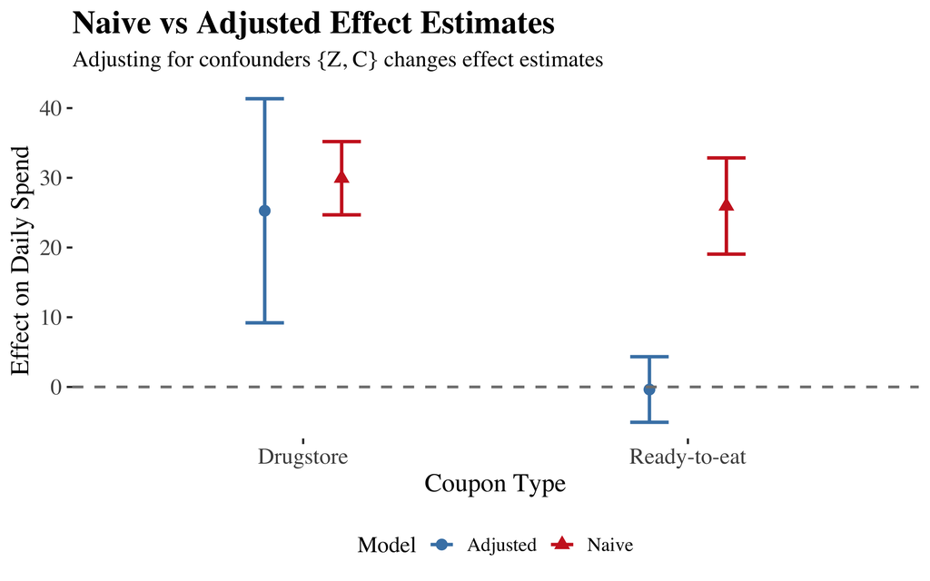

```r
# Plot with error bars (uses conf.low/conf.high from full table)
comparison_table |>
  ggplot(aes(x = coupon_type, y = estimate, color = model, shape = model)) +
  geom_point(size = 3, position = position_dodge(width = 0.4)) +
  geom_errorbar(aes(ymin = conf.low, ymax = conf.high),
                width = 0.2, linewidth = 1., position = position_dodge(width = 0.4)) +
  geom_hline(yintercept = 0, linetype = "dashed", color = "gray50", linewidth = 0.8) +
  scale_color_manual(values = c("Naive" = "firebrick3", "Adjusted" = "steelblue")) +
  labs(
    title = "Naive vs Adjusted Effect Estimates",
    subtitle = "Adjusting for confounders {Z, C} changes effect estimates",
    x = "Coupon Type",
    y = "Effect on Daily Spend",
    color = "Model", shape = "Model"
  ) +
  theme_tufte(base_size = 14) +
  theme(
    legend.position = "bottom",
    plot.title = element_text(size = 20, face = "bold"),
    plot.subtitle = element_text(size = 14),
    axis.title = element_text(size = 16),
    axis.text = element_text(size = 14),
    legend.text = element_text(size = 12),
    legend.title = element_text(size = 14)
  ) -> p
p
```

## Causal Machine Learning

The classical regression approach above assumes a linear, additive relationship between covariates and outcome. [Langen & Huber (2023)](https://journals.plos.org/plosone/article?id=10.1371/journal.pone.0278937) use a causal ML approach to the problem – **Causal forests** ([Wager & Athey, 2018](https://www.tandfonline.com/doi/full/10.1080/01621459.2017.1319839#abstract); [Athey, Tibshirani & Wager, 2019](https://projecteuclid.org/journals/annals-of-statistics/volume-47/issue-2/Generalized-random-forests/10.1214/18-AOS1709.full)) relax this assumption while maintaining the same identification logic.

We will explore this further in the next post.